# data_visualisations_markdown

MC

2022-11-10

Task:

Convert to R Markdown some of the R scripts you’ve created previously. Add headers, hide output that’s not needed etc.

Challenges:

Work out how to include a computed variable as part of your narrative text (e.g., “The mean height of humans in the starwars universe is…”) Work out how to make your visualisation smaller by changing its width Work out how to insert an image that is saved on your computer Work out how to label your code chunks, to make navigation easier

# Setup

Load in packages.

```r
library (tidyverse)
library(Hmisc)
```

# Scatterplots

## Scatterplot with 2 factors (manufacturer, fuel economy)

### Scatterplot 1.1

Create scatterplot with manufacturer as x and fuel economy as y.

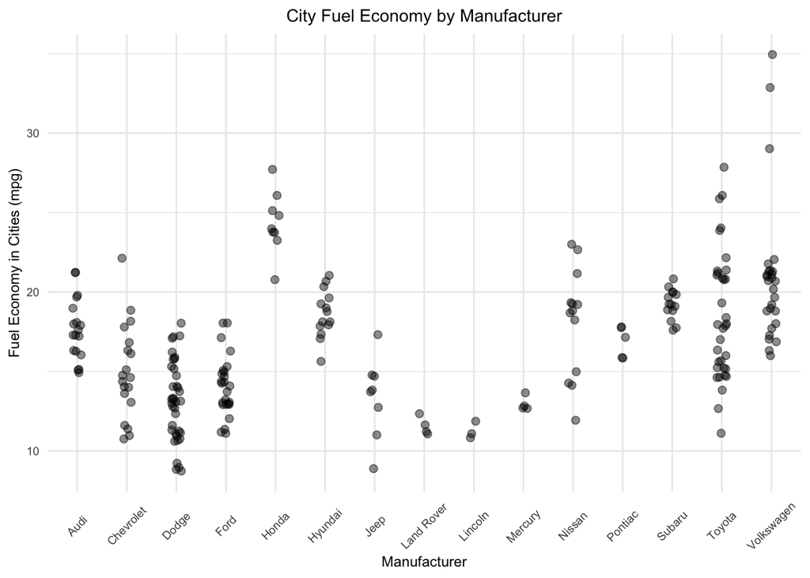

```r
mpg %>%
  mutate(manufacturer = str_to_title(manufacturer)) %>%
  ggplot(aes(x = manufacturer, y = cty)) +
  geom_jitter(width = .1, alpha = .45, size = 2) +
  theme_minimal() +
  theme(axis.text.x = element_text(angle = 45, vjust = .5, hjust = .5)) +
  theme(text = element_text(size = 9)) +
  labs(title = "City Fuel Economy by Manufacturer",
       x = "Manufacturer",
       y = "Fuel Economy in Cities (mpg)") +
  theme(plot.title = element_text(hjust = .5))
```

### Scatterplot 1.2

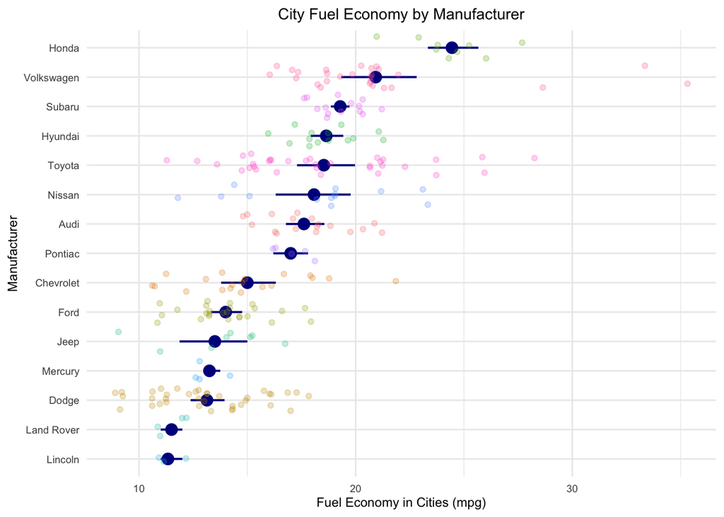

```r
mpg %>%
  mutate(manufacturer = str_to_title(manufacturer)) %>%
  ggplot(aes(x = fct_reorder(manufacturer, .fun = mean, cty), y = cty, color = manufacturer)) +
  stat_summary(fun.data = mean_cl_boot, color = "dark blue", size = .7) +
  geom_jitter(alpha = .25) +
  theme_minimal() +
  theme(axis.text.x = element_text(angle = 0, vjust = .5, hjust = .5)) +
  theme(text = element_text(size = 9)) +
  labs(title = "City Fuel Economy by Manufacturer",
       x = "Manufacturer",
       y = "Fuel Economy in Cities (mpg)") +
  theme(plot.title = element_text(hjust = .5)) +
  guides(color = "none") +
  coord_flip()
```

## Scatterplot with 3 variables (engine displacement, fuel economy, car class)

### Scatterplot 2.1

Creating a visually different scatterplot where x (engine displacement) over y (fuel economy) is separated by a separate variable of car class.

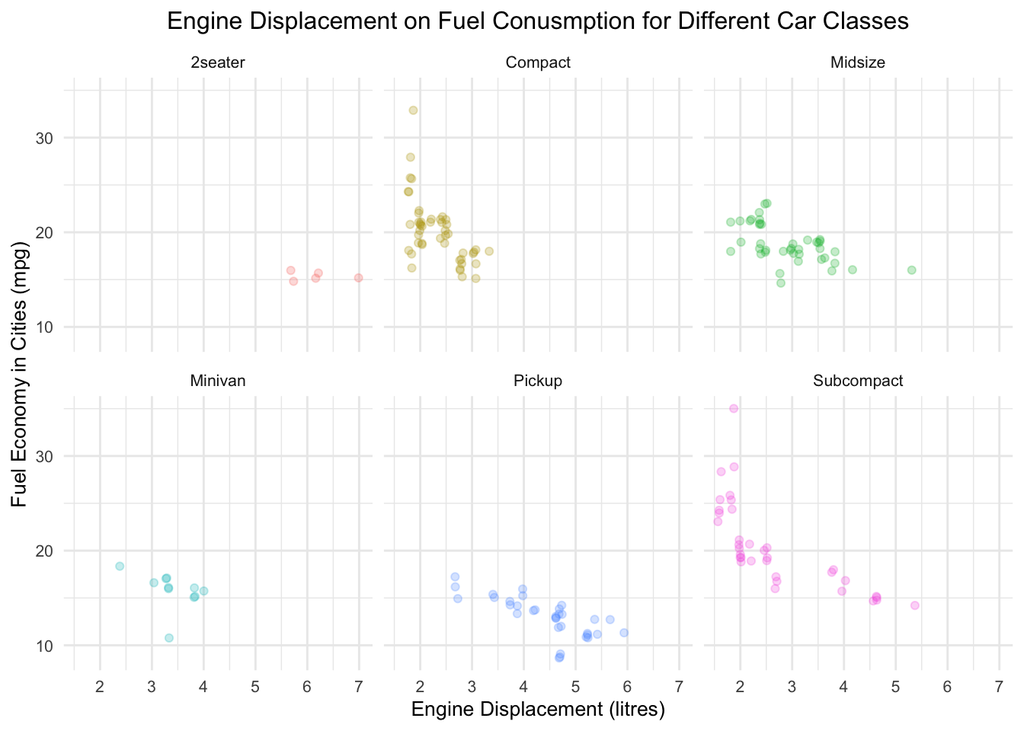

```r
mpg %>%
  filter(class != "suv") %>% #Are car class are included excpet for SUVs
  mutate(class = str_to_title(class)) %>%
  ggplot(aes(x = displ, y = cty, color = class)) +
  geom_jitter(alpha = .25) +
  theme_minimal() +
  theme(text = element_text(size = 10)) +
  guides(color = "none") +
  facet_wrap(~ class) +
  labs(title = "Engine Displacement on Fuel Conusmption for Different Car Classes",
       x = "Engine Displacement (litres)",
       y = "Fuel Economy in Cities (mpg)") +
  theme(plot.title = element_text(hjust = .5))
```

### Scatterplot 2.2

Creating a scatterplot with 3 factors all on the same graph. Added with smooth trend line.

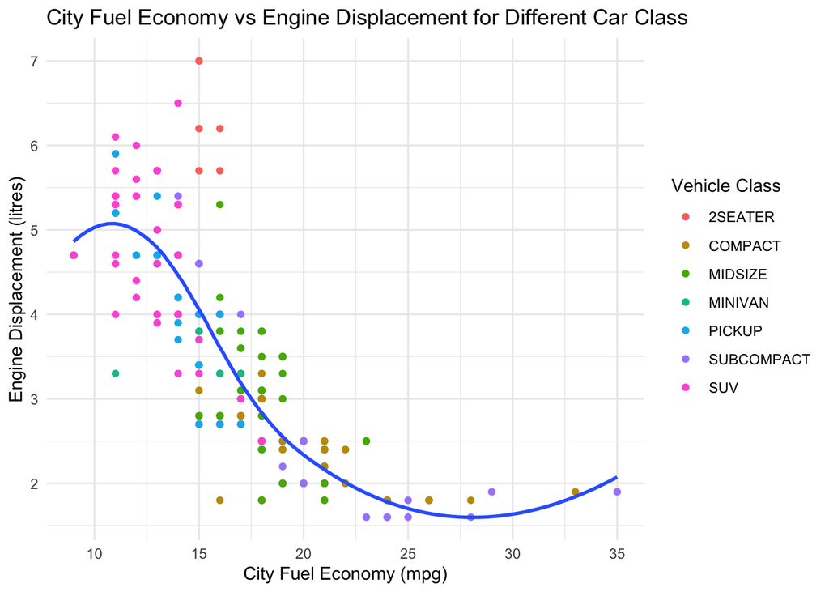

```r
mpg %>%
  mutate(class = str_to_upper(class)) %>%
  ggplot(aes(x = cty, y = displ)) +
  geom_point(aes(color = class)) +
  geom_smooth(se = FALSE) + #SE = FALSE adde trend line without displauing standard error
  theme(text = element_text(size = 13)) +
  theme_minimal() +
  labs(title = "City Fuel Economy vs Engine Displacement for Different Car Class",
       x = "City Fuel Economy (mpg)",
       y = "Engine Displacement (litres)",
       color = "Vehicle Class")
```

# Histograms

## Histogram (Engine Size, count)

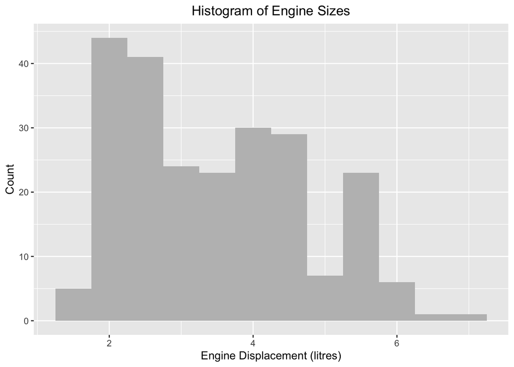

```r
mpg %>%
  ggplot(aes(x = displ)) +
  geom_histogram(binwidth = .5, fill = "grey") +
  labs(title = "Histogram of Engine Sizes",
       x = "Engine Displacement (litres)",
       y = "Count") +
  theme(plot.title = element_text(hjust = .5))
```

# Challenges

## Challenge 1

The average fuel use of popular car models from 1999 to 2008 in cities is 16.8589744 city miles per gallon.

## Challenge 2

The the size of the displayed histogram above is changed with out.width.

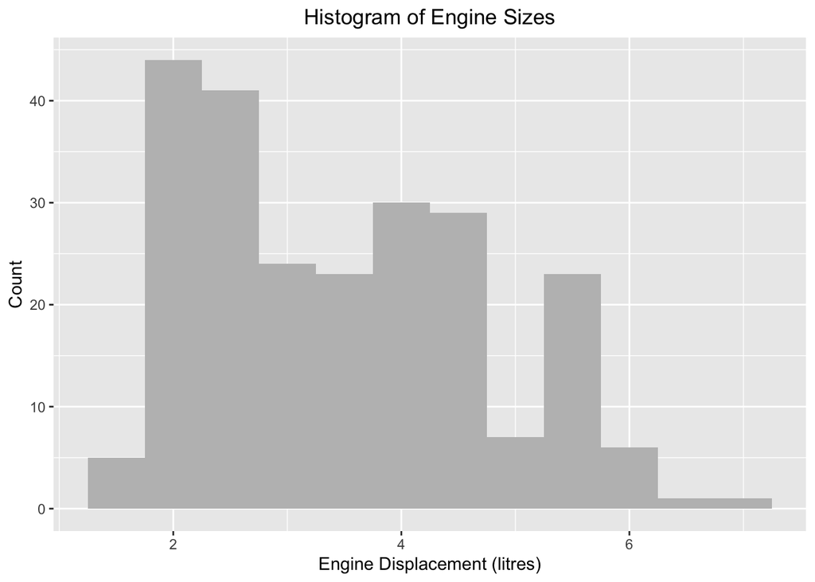

The size of the displayed histogram above is changed with fig.dim.

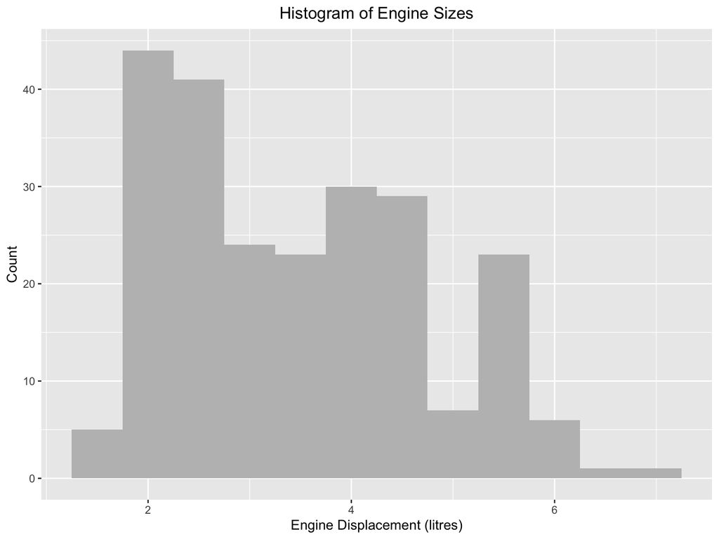

## Challenge 3

Inserting images from a directory in my computer. It is important that that image is in the specified directory that the markdown is in.

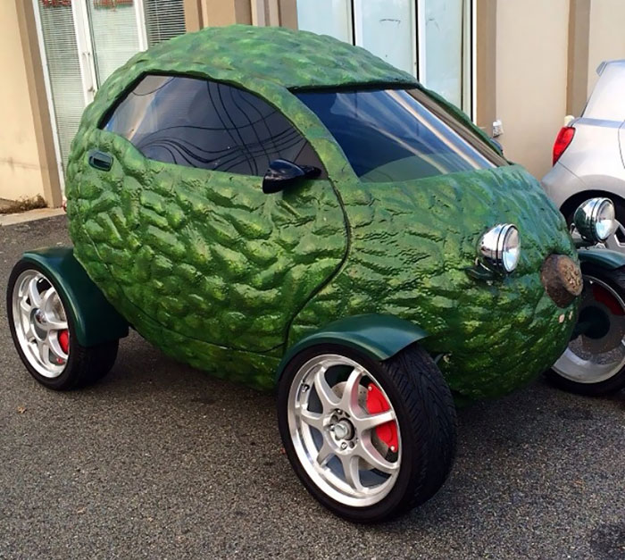

Avocado Car

Using R code to insert the image.

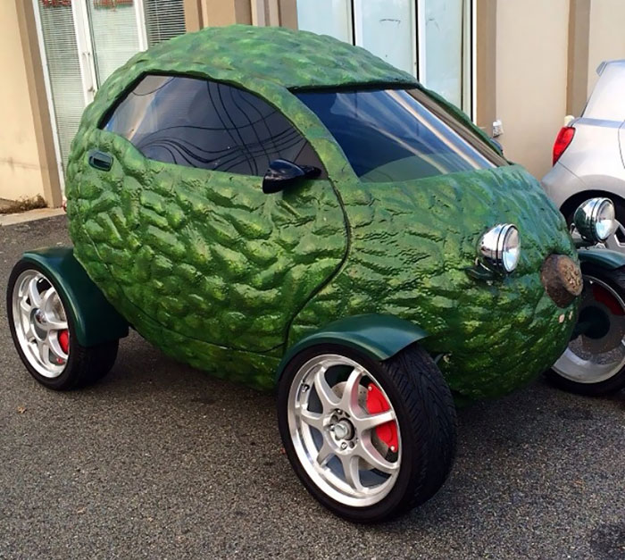

```r
knitr::include_graphics("funny_cars.jpg")
```

## Challenge 4

Labelling the code chunks:

````markdown
```{r whatever_name_you_choose}
knitr::include_graphics("funny_cars.jpg")
```
````